# fsbrain visualization examples

Tim Schäfer

Septmember 16, 2021

## Example data

First we specify a subjects dir and the subject we want to use. Feel free to replace this with your data.

```r
library('fsbrain')
sjd = '~/data/subject1_only'
sj = 'subject1'
```

Now increase the figure size.

```r
fsbrain.set.default.figsize(1000, 1000);
```

## Visualizing native space morphometry data: cortical thickness

Let’s start with a basic example and plot cortical thickness on the surface of our subject:

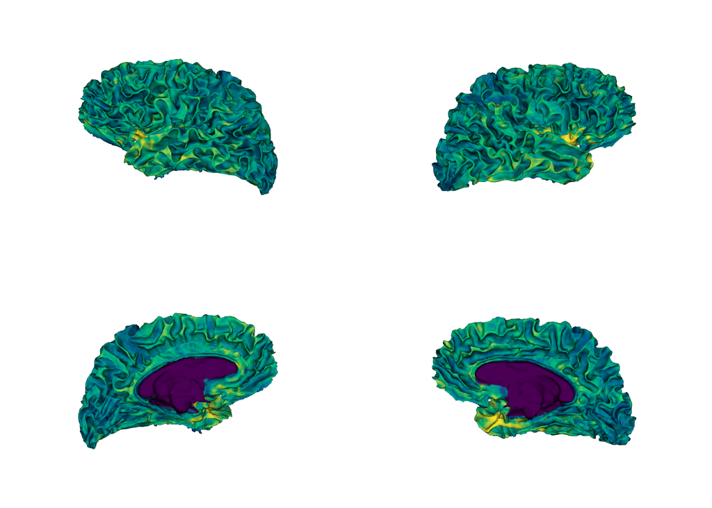

```r
vis.subject.morph.native(sjd, sj, 'thickness')
```

This loaded the morphometry data files `surf/lh.thickness` and `surf/rh.thickness` of the subject, applied a colormap to the values, and visualized the results on the white surface, i.e., the brain surface meshes in the files `surf/lh.white` and `surf/rh.white`.

## Changing the view and masking the medial wall

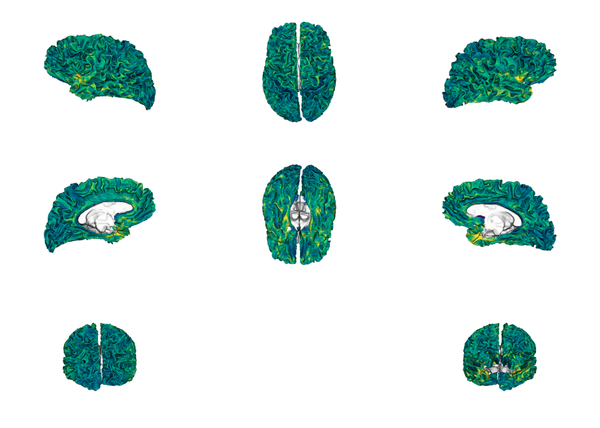

```r
vis.subject.morph.native(sjd, sj, 'thickness', views='t9', cortex_only = TRUE)
```

The mask for the medial wall was created by setting the data of all vertices which are not part of the cortex to `NA`, based on the cortex definition in the label files `label/lh.cortex.label` and `label/rh.cortex.label` of the subject.

## Visualizing data with outliers, tails, or other non-normal data

Next, we will try a third view, add a colorbar, use the pial surface, and plot something different. Let’s try mean curvature.

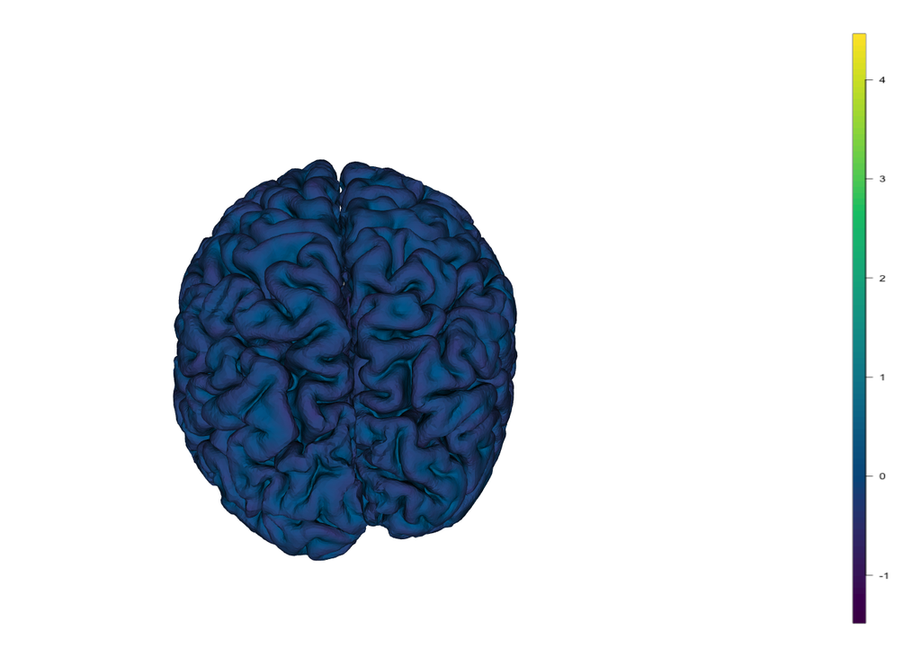

```r
vis.subject.morph.native(sjd, sj, 'curv', views='si', cortex_only = TRUE, draw_colorbar = 'vertical', surface = 'pial')
```

That does not look very exciting. Why? The curvature data has long tails and is far from Normal:

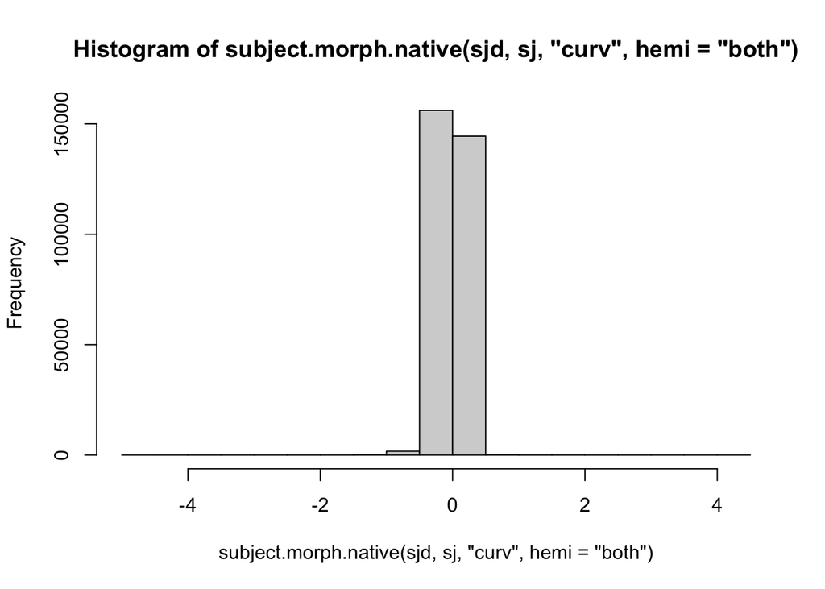

```r
hist(subject.morph.native(sjd, sj, 'curv', hemi = 'both'))
```

There are various solutions to this problem, but for plotting, the easiest one is to apply some function that removes outliers or performs some other sort of data transformation before plotting. You can pass any transformation function you want using *rglactions*, in the next example we clip the data.

The `si` view is single interactive view, and you can rotate the brain with your mouse in an R session. That is not possible in this markdown document though, so better try it in R. We will use another view here and switch back to the white surface.

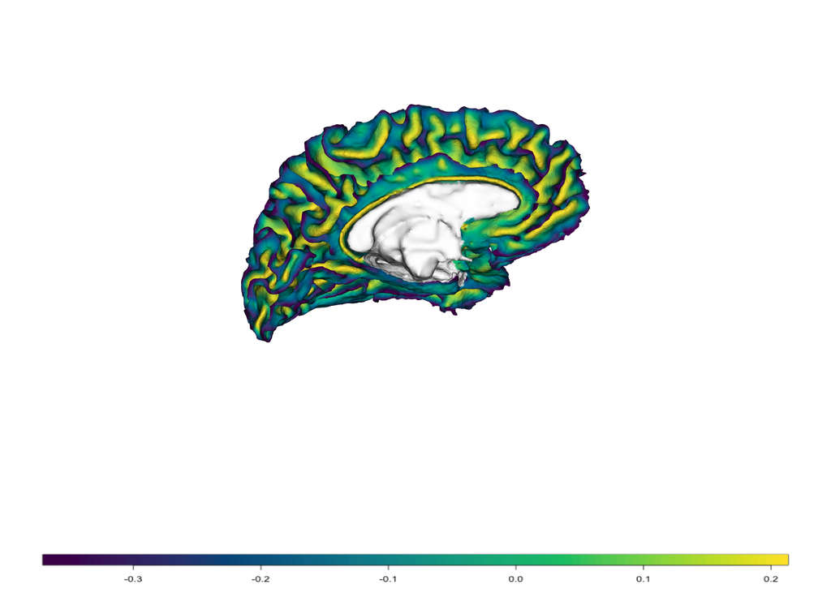

```r
vis.subject.morph.native(sjd, sj, 'curv', views='sd_medial_lh', cortex_only = TRUE, draw_colorbar = 'horizontal',  rglactions=list('trans_fun'=clip.data))
```

That looks more suitable.

## Standard space data

In group studies, you typically have a single standard space that data gets mapped to for comparison. For FreeSurfer surface data, typically the *fsaverage* subject is used, but you could create and use your own template, of course. Let’s have a look at some standard space data mapped to fsaverage. We will use sulcal depths in this example.

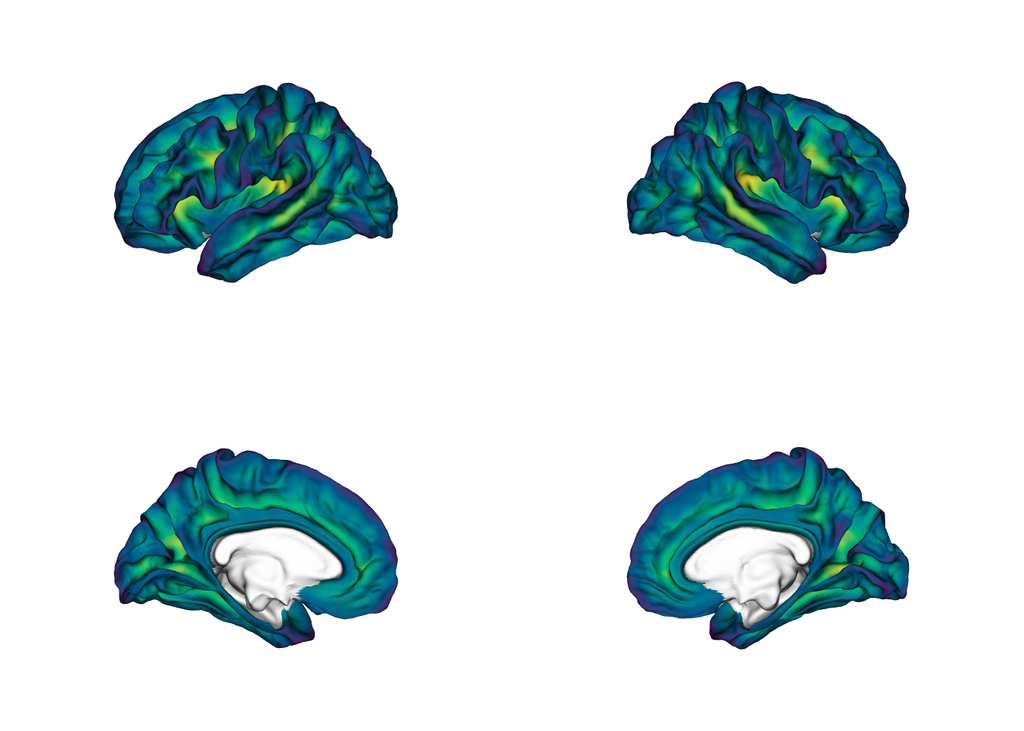

```r
vis.subject.morph.standard(sjd, sj, 'sulc', cortex_only = TRUE, fwhm="5");
```

When data is mapped to standard space, they will get smoothed and different versions with a number of kernel settings will be available after running FreeSurfer’s `recon-all` with the `qcache` option. That is what the `fwhm` parameter is about. Try different values depending on what files you have, start with “5”, “10”, or “15”.

## Adjusting the colormap

A great and popular sequential palette is `viridis` from the `viridis` package. Here we used the `makecmap_options` parameter to use it:

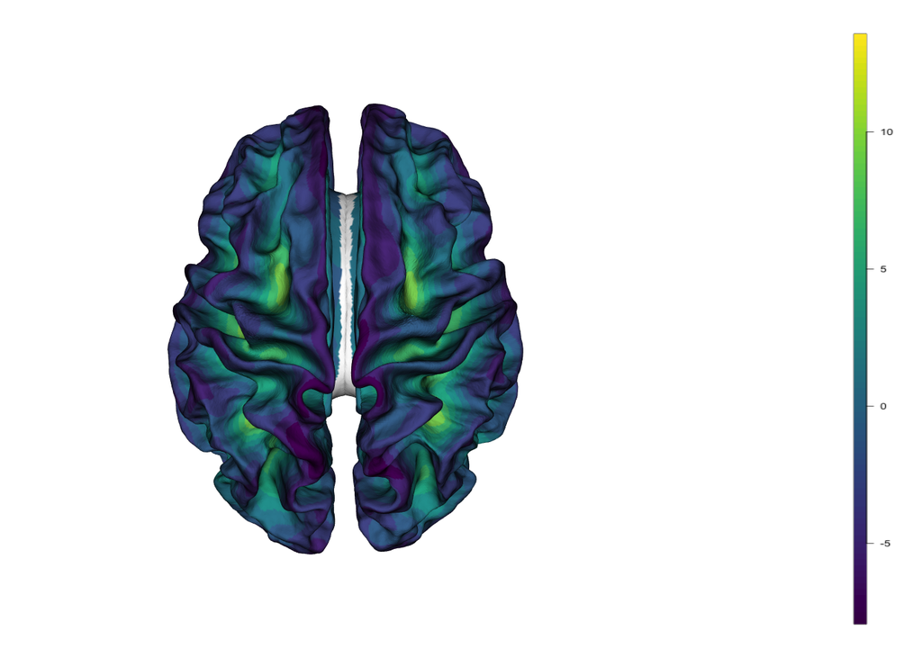

```r
vis.subject.morph.standard(sjd, sj, 'sulc', cortex_only = TRUE, fwhm="15", makecmap_options = list('colFn'=viridis::viridis), draw_colorbar = T, views='sd_dorsal');
```

Try some different colormaps and see which one you like best. If you want to use interpolated colormaps with many colors based on the `RColorBrewer` palettes (which have too few colors for morphometry data in most cases), try something like this:

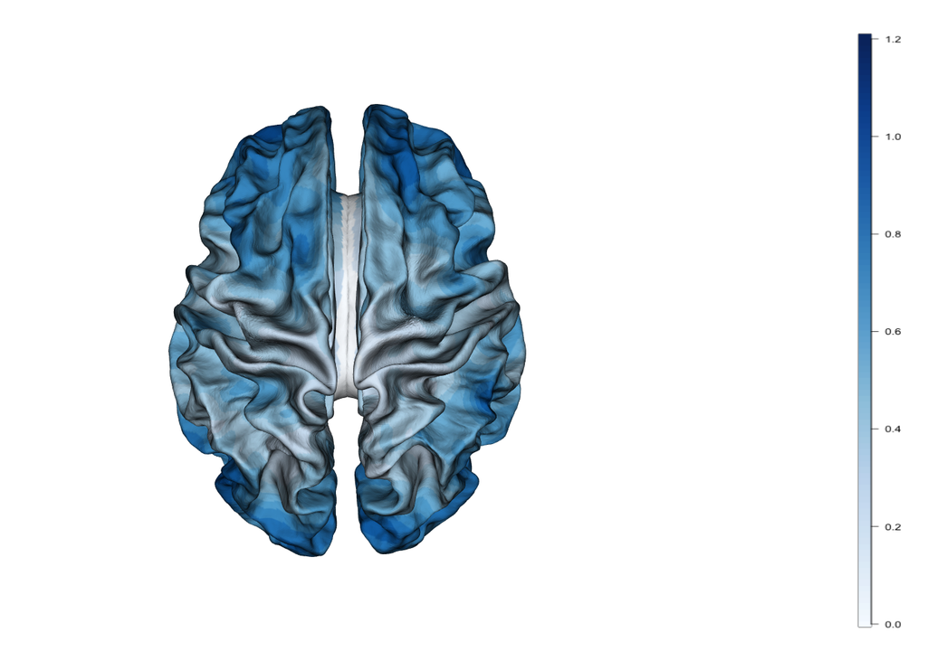

```r
manyblues = colorRampPalette(RColorBrewer::brewer.pal(9, name="Blues"));
vis.subject.morph.standard(sjd, sj, 'area', makecmap_options = list('colFn'=manyblues), draw_colorbar = T, views='sd_dorsal');
```

If you prefer a smoother colorbar, try increasing the number of colors by adapting the `makecmap_options` parameter, e.g.:

```r
makecmap_options = list('colFn'=manyblues, 'n=100')
```

## Plotting atlas data

Plotting a brain parcellation is straightforward, here we plot the Desikan atlas:

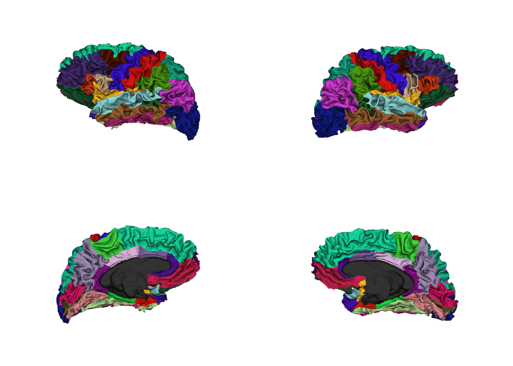

```r
vis.subject.annot(sjd ,sj, 'aparc');
```

This loads the Desikan labels for the subject from the files `label/?h.aparc.annot` and uses colors from the contained color lookup table.

By default, FreeSurfer computes brain parcellations for the following brain atlases:

- Desikan-Killiany atlas (‘aparc’)
- DKT atlas (‘aparc.DKTatlas40’)
- Destrieux atlas (‘aparc.a2009s’)

Of course, one can select different view angles, surfaces, and other options as illustrated above for morphometry data.

## Annotation Outlines

A unique option that is available with annotations is to draw outlines around them:

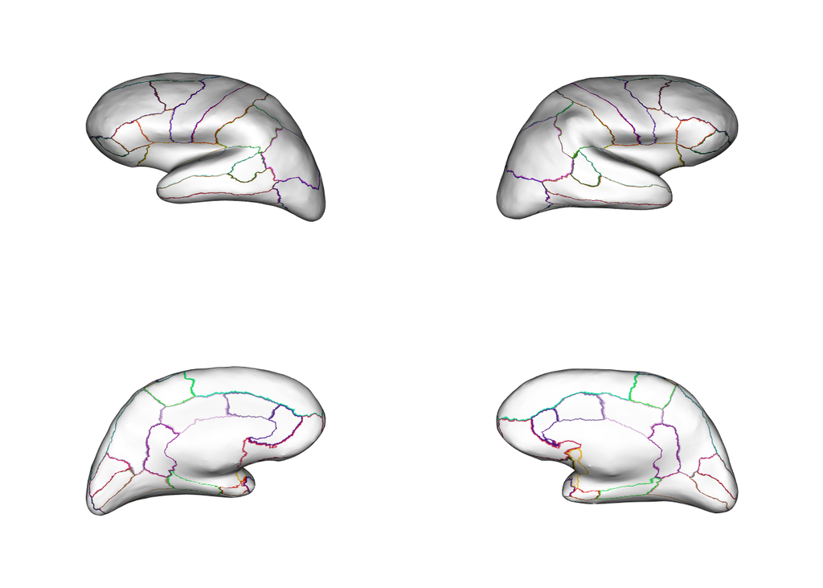

```r
vis.subject.annot(sjd ,sj, 'aparc', outline = TRUE, surface="inflated");
```

You can customize the look of the outlines (or region borders) by passing a list of extra arguments to `annot.outline` instead of a logical value, see the documentation for details. Here is a more complex example that draws a green border around the middle temporal gyrus and a blue border around the postcentral gyrus:

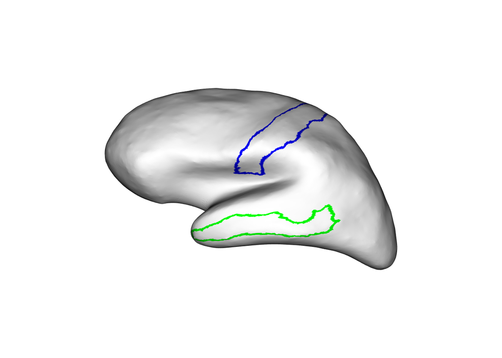

```r
vis.subject.annot(sjd ,sj, 'aparc', outline=list('outline_color'=c('green', 'blue'), 'limit_to_regions'=c('middletemporal', 'postcentral'), expand_inwards=2L), surface="inflated", views="sd_lateral_lh");
```

Note that you can also use this function for drawing borders around arbitrary custom regions (activation cluster or whatever). A custom region really is nothing but a label, and you can convert a label (or several labels) to an annotation using `label.to.annot`.

### Labels

Here is an example for visualizing a label:

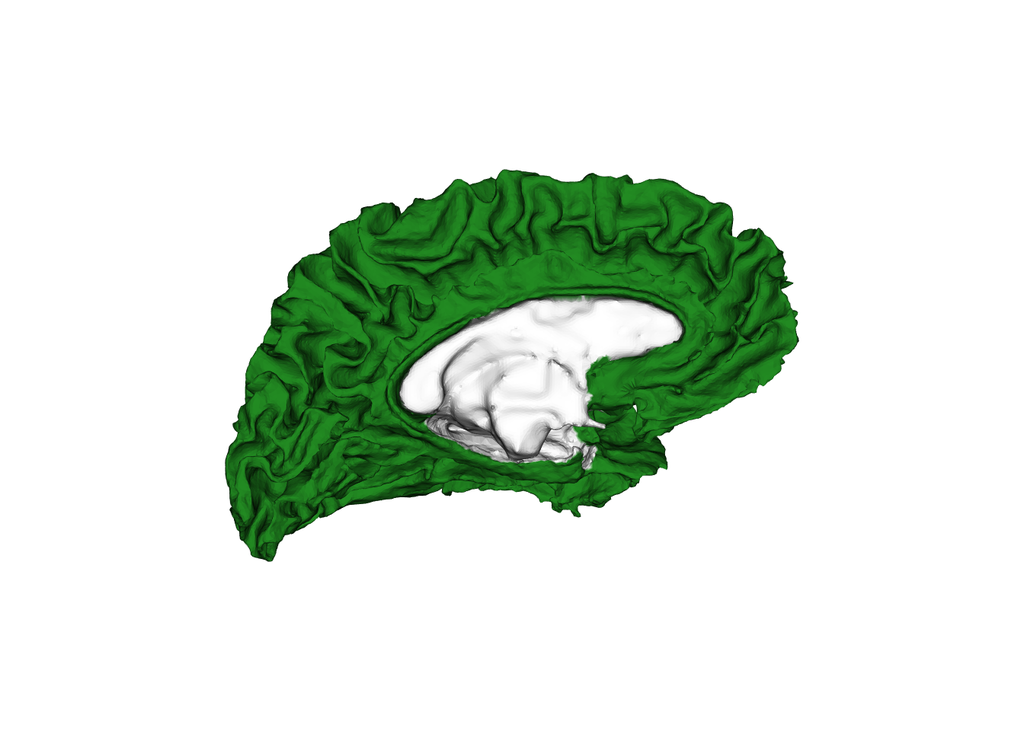

```r
vis.subject.label(sjd, sj, 'cortex', hemi='lh', views = 'sd_medial_lh');
```

Here, the file `label/lh.cortex.label` was used. If you want to visualize preloaded data, there is no need to save it to a file first, just use the `vis.labeldata.on.subject` function.

### Results: region-based

If you perform atlas based analyses, you will typically get one result (significance, effect size, or whatever) per atlas region. The function `vis.region.values.on.subject` comes in very handy here. Typically the results are displayed on the fsaverage subject, but you can use any subject you want:

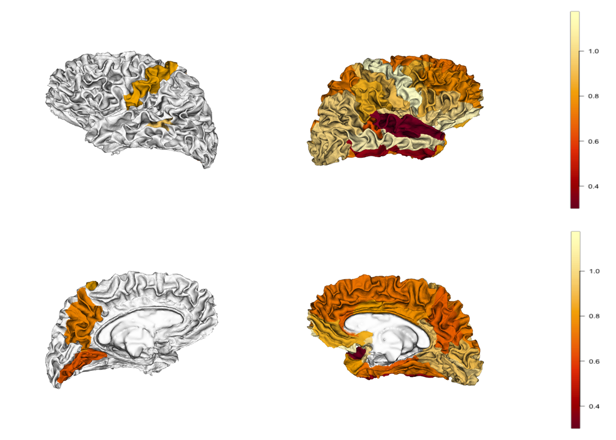

```r
atlas = 'aparc';   # Desikan atlas
# For the left hemisphere, we just assign a subset of the
# atlas regions. The others will get the default value.
lh_region_value_list = list("bankssts"=0.9, "precuneus"=0.7, "postcentral"=0.8, "lingual"=0.6);
# For the right hemisphere, we retrieve the full list of regions for
# the atlas, and assign random values to all of them.
atlas_region_names = get.atlas.region.names(atlas, template_subjects_dir = sjd, template_subject = sj);
rh_region_value_list = rnorm(length(atlas_region_names), 0.8, 0.2);
names(rh_region_value_list) = atlas_region_names;

vis.region.values.on.subject(sjd, sj, atlas, lh_region_value_list, rh_region_value_list, draw_colorbar = T);
```

If your data are symmetric around zero, e.g., t-values, you should use a symmetric colormap. An example is available in the default makecmap_topions settings of the `vis.symmetric.data.on.subject` function, which we will use next.